# Points, lines, and polygons in R

J Camilo Fagua and Patrick Jantz

August 2023

# **Objectives**

1. Learn the basic logic and construction of the vector spatial features (points, lines, polygons) in R.
2. Learn some of the basic operations with vector spatial features in R.
3. Understand the R logic to process vector spatial features.
4. Review some of the main R packages to process vector spatial feature in R.

# **Introduction**

This tutorial is focused on providing you the tools required to build, read, and project vector spatial feature in R. There are three main packages used by the R community to bring vector spatial feature data into R: 1) sp, 2) rgdal, and 3) raster. In this tutorial, we also will use the package maptools and tidyverse. Let’s go to start. You need to make sure the following packages are installed and loaded into your RStudio session.

```r
# To clean environment
rm(list = ls(all.names = TRUE))
gc()
```

```
##          used (Mb) gc trigger (Mb) max used (Mb)
## Ncells 520151 27.8    1155952 61.8   660385 35.3
## Vcells 949640  7.3    8388608 64.0  1772588 13.6
```

```r
#To install packages
#install.packages("sp")
#install.packages("rgdal")
#install.packages("raster")
#install.packages("maptools")
#install.packages("tidyverse")
#install.packages("sf")
#install.packages("rgeos")

#To open libraries
library("sp")
library("rgdal")
library("raster")
library("maptools")
library("tidyverse")
library("sf") #***********
library("rgeos")
```

The package sp is the mama-package of all the spatial packages. sp revolutionized the spatial analysis in R when it was built. Team sp created a set of new data classes that integrate the data.frame objects of R with the vector spatial features: points, lines, and polygons. You can see the catalogue of new data classes supported by sp by calling the function getClass().

```r
getClass("Spatial")
```

```
## Class "Spatial" [package "sp"]
##
## Slots:
##
## Name:         bbox proj4string
## Class:      matrix         CRS
##
## Known Subclasses:
## Class "SpatialPoints", directly
## Class "SpatialMultiPoints", directly
## Class "SpatialGrid", directly
## Class "SpatialLines", directly
## Class "SpatialPolygons", directly
## Class "SpatialPointsDataFrame", by class "SpatialPoints", distance 2
## Class "SpatialPixels", by class "SpatialPoints", distance 2
## Class "SpatialMultiPointsDataFrame", by class "SpatialMultiPoints", distance 2
## Class "SpatialGridDataFrame", by class "SpatialGrid", distance 2
## Class "SpatialLinesDataFrame", by class "SpatialLines", distance 2
## Class "SpatialPixelsDataFrame", by class "SpatialPoints", distance 3
## Class "SpatialPolygonsDataFrame", by class "SpatialPolygons", distance 2
```

The subclasses followed by DataFrame in the above catalogue, such as SpatialPointsDataFrame, include additional attributes in the form of a data.frame. For example, if you were working with a SpatialPolygon object, this object would only include the spatial information required to plot the block group polygons. With a SpatialPolygonDataFrame, in a single object, you have both the polygon data and additional data stored in a data.frame (think in the attribute tables of ArcGis or Qgis).

# **Creating spatial objects from scratch**

## **Spatial points**

We are going to start generating a set of 10 points on the unit square [0, 1] and [0, 1]. The function runif() creates random numbers that follow a uniform distribution while the function round() returns rounded values to the specified number of decimal places.

```r
xc = round(runif(10), 2)
yc = round(runif(10), 2)
xy = cbind(xc, yc)
xy
```

```
##         xc   yc
##  [1,] 0.62 0.48
##  [2,] 0.41 0.47
##  [3,] 0.74 0.97
##  [4,] 0.44 0.24
##  [5,] 0.37 0.44
##  [6,] 0.27 0.09
##  [7,] 0.60 0.41
##  [8,] 0.95 0.64
##  [9,] 0.91 0.77
## [10,] 0.25 0.67
```

```r
class(xy)
```

```
## [1] "matrix" "array"
```

The matrix xy can be converted into a SpatialPoints object by the function SpatialPoints. You can observe the change of the object type by using the function class().

```r
xy.sp = SpatialPoints(xy)
class(xy.sp)
```

```
## [1] "SpatialPoints"
## attr(,"package")
## [1] "sp"
```

```r
xy.sp
```

```
## class       : SpatialPoints
## features    : 10
## extent      : 0.25, 0.95, 0.09, 0.97  (xmin, xmax, ymin, ymax)
## crs         : NA
```

Although the Coordinate Reference System (CRS) argument is NA (Not-Available), we can plot and retrieve the coordinates of xy.sp because this is a spatial object. Observe that xy.cc is a matrix.

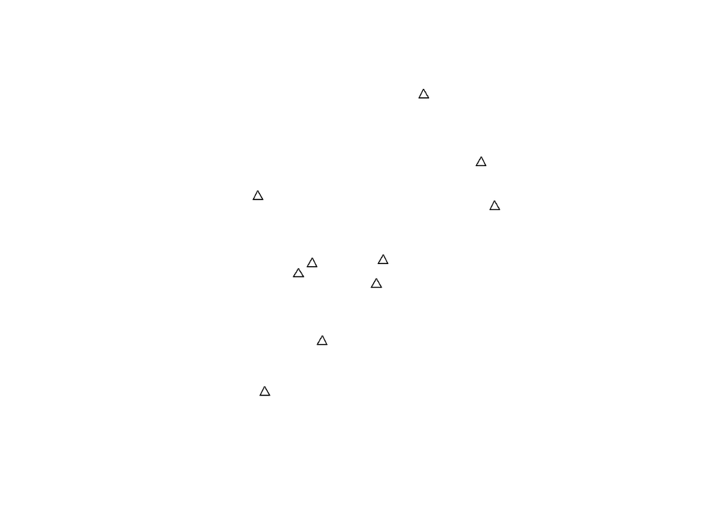

```r
plot(xy.sp, pch = 2)
```

```r
xy.cc = coordinates(xy.sp)
class(xy.cc)
```

```
## [1] "matrix" "array"
```

You can obtain the coordinates and spatial bounding of xy.sp with the functions coordinates() and bbox(), respectively. This type of information can be useful when you are working with polygons created by other people.

```r
coordinates(xy.sp)
```

```
##         xc   yc
##  [1,] 0.62 0.48
##  [2,] 0.41 0.47
##  [3,] 0.74 0.97
##  [4,] 0.44 0.24
##  [5,] 0.37 0.44
##  [6,] 0.27 0.09
##  [7,] 0.60 0.41
##  [8,] 0.95 0.64
##  [9,] 0.91 0.77
## [10,] 0.25 0.67
```

```r
xy.cc = coordinates(xy.sp)#To create a data.frame with the coordinates (it is used a lot in spatial modeling)
class(xy.cc)
```

```
## [1] "matrix" "array"
```

```r
bbox(xy.sp)
```

```
##     min  max
## xc 0.25 0.95
## yc 0.09 0.97
```

We can also create points with attributes (SpatialPointsDataFrame) by building them from a SpatialPoints object (such as xy.sp) and a data.frame containing the attributes.

```r
#To build the data.frame (df) with the attributes
df = data.frame(z1 = round(5 + rnorm(10), 2), z2 = 20:29)
df
```

```
##      z1 z2
## 1  5.25 20
## 2  4.35 21
## 3  4.75 22
## 4  5.37 23
## 5  5.88 24
## 6  5.21 25
## 7  5.21 26
## 8  4.12 27
## 9  4.92 28
## 10 5.74 29
```

```r
#To join the SpatialPoint (x.ysp) to the data.frame (df)
xy.spdf = SpatialPointsDataFrame(xy.sp, df)
xy.spdf
```

```
## class       : SpatialPointsDataFrame
## features    : 10
## extent      : 0.25, 0.95, 0.09, 0.97  (xmin, xmax, ymin, ymax)
## crs         : NA
## variables   : 2
## names       :   z1, z2
## min values  : 4.12, 20
## max values  : 5.88, 29
```

```r
class(xy.spdf)
```

```
## [1] "SpatialPointsDataFrame"
## attr(,"package")
## [1] "sp"
```

## **Spatial lines**

Spatial lines are retrieved from external sources frequently; however, the following example show how to build an object of class SpatialLines from scratch. We firstly create the points that lines are going to follow. We secondly create the lines using these points and the function Line(). We thirdly put these lines in a list separately; these lines are not spatial object at this point. We finally merge both lines and give spatial properties with the function SpatialLines(). Note that the lines objects must be given character ID values, and that these values must be unique for Lines objects combined in a SpatialLines objects.

```r
# To create the points that the lines follow.
l1 = cbind(c(1,2,3),c(3,2,2))
l1a = cbind(l1[,1]+.05,l1[,2]+.05)
l2 = cbind(c(1,2,3),c(1,1.5,1))

# To create the lines.
Sl1 = Line(l1)
Sl1a = Line(l1a)
Sl2 = Line(l2)

# To put these lines in a list separately.
S1 = Lines(list(Sl1, Sl1a), ID="a")
S2 = Lines(list(Sl2), ID="b")
#
Sl = SpatialLines(list(S1,S2))
summary(Sl)
```

```
## Object of class SpatialLines
## Coordinates:
##   min  max
## x   1 3.05
## y   1 3.05
## Is projected: NA
## proj4string : [NA]
```

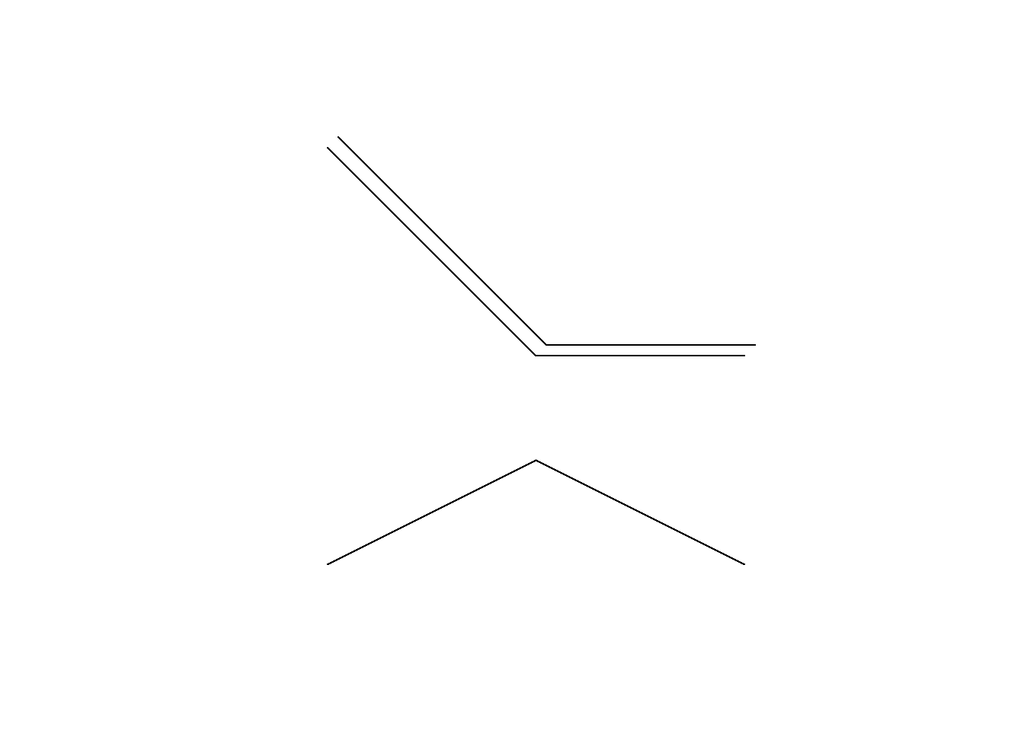

```r
plot(Sl)
```

We can create a SpatialLines object with attributes by attaching an attribute table (data.frame). In the next codes, the function sapply() applies the function slot() to each line object to generate an ID.

```r
df_2 = data.frame(z = c(1,2), row.names=sapply(slot(Sl, "lines"), function(x) slot(x, "ID")))
Sldf = SpatialLinesDataFrame(Sl, data = df_2)
summary(Sldf)
```

```
## Object of class SpatialLinesDataFrame
## Coordinates:
##   min  max
## x   1 3.05
## y   1 3.05
## Is projected: NA
## proj4string : [NA]
## Data attributes:
##        z
##  Min.   :1.00
##  1st Qu.:1.25
##  Median :1.50
##  Mean   :1.50
##  3rd Qu.:1.75
##  Max.   :2.00
```

```r
#To verify ID (a and b) and the structure of Sldf.
str(Sldf)
```

```
## Formal class 'SpatialLinesDataFrame' [package "sp"] with 4 slots
##   ..@ data       :'data.frame':  2 obs. of  1 variable:
##   .. ..$ z: num [1:2] 1 2
##   ..@ lines      :List of 2
##   .. ..$ :Formal class 'Lines' [package "sp"] with 2 slots
##   .. .. .. ..@ Lines:List of 2
##   .. .. .. .. ..$ :Formal class 'Line' [package "sp"] with 1 slot
##   .. .. .. .. .. .. ..@ coords: num [1:3, 1:2] 1 2 3 3 2 2
##   .. .. .. .. ..$ :Formal class 'Line' [package "sp"] with 1 slot
##   .. .. .. .. .. .. ..@ coords: num [1:3, 1:2] 1.05 2.05 3.05 3.05 2.05 2.05
##   .. .. .. ..@ ID   : chr "a"
##   .. ..$ :Formal class 'Lines' [package "sp"] with 2 slots
##   .. .. .. ..@ Lines:List of 1
##   .. .. .. .. ..$ :Formal class 'Line' [package "sp"] with 1 slot
##   .. .. .. .. .. .. ..@ coords: num [1:3, 1:2] 1 2 3 1 1.5 1
##   .. .. .. ..@ ID   : chr "b"
##   ..@ bbox       : num [1:2, 1:2] 1 1 3.05 3.05
##   .. ..- attr(*, "dimnames")=List of 2
##   .. .. ..$ : chr [1:2] "x" "y"
##   .. .. ..$ : chr [1:2] "min" "max"
##   ..@ proj4string:Formal class 'CRS' [package "sp"] with 1 slot
##   .. .. ..@ projargs: chr NA
```

## **Spatial Polygons**

Now we will build polygons from scratch. The function cbind() allows the construction of the points that form the polygons while the function Polygon() creates no-spatial polygons. The argument hole = TRUE of Sr4 is for setting a polygon as hole.

```r
#To create no-spatial polygons
Sr1 = Polygon(cbind(c(2,4,4,1,2),c(2,3,5,4,2)))
Sr2 = Polygon(cbind(c(5,4,2,5),c(2,3,2,2)))
Sr3 = Polygon(cbind(c(4,4,5,10,4),c(5,3,2,5,5)))
Sr4 = Polygon(cbind(c(5,6,6,5,5),c(4,4,3,3,4)), hole = TRUE)
Sr1@coords #To see coordinates
```

```
##      [,1] [,2]
## [1,]    2    2
## [2,]    4    3
## [3,]    4    5
## [4,]    1    4
## [5,]    2    2
```

```r
#To put the polygons in a list and add IDs ("s1","s2","s3").
Srs1 = Polygons(list(Sr1), "s1")
Srs2 = Polygons(list(Sr2), "s2")
Srs3 = Polygons(list(Sr3, Sr4), "s3/s4")
```

Note that the Polygons objects must be given character ID values, and that these values must be unique for Polygons objects combined in a SpatialPolygons object. Now we are going to create the spatial polygon.

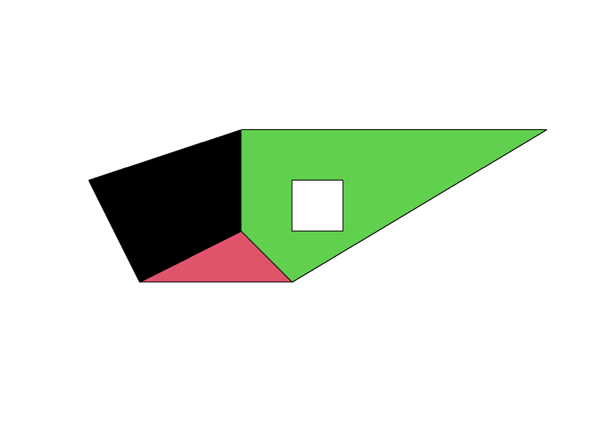

```r
#To create the final spatial polygons and plot it.
SpP = SpatialPolygons(list(Srs1,Srs2,Srs3), 1:3)
plot(SpP, col = 1:3)
```

As we did for spatial point and lines, we can attach attributes to the spatial polygons. Polygons with attributes (objects of class SpatialPolygonsDataFrame) are built from the SpatialPolygons object (topology) and the attributes (data.frame). The row.names of the attributes data frame are matched with the ID slots of the SpatialPolygons object, and the rows of the data frame will be re-ordered if necessary.

```r
attr = data.frame(a=1:3, row.names=c("s3/s4", "s2", "s1"))
attr
```

```
##       a
## s3/s4 1
## s2    2
## s1    3
```

```r
SrDf = SpatialPolygonsDataFrame(SpP, attr)
SrDf
```

```
## class       : SpatialPolygonsDataFrame
## features    : 3
## extent      : 1, 10, 2, 5  (xmin, xmax, ymin, ymax)
## crs         : NA
## variables   : 1
## names       : a
## min values  : 1
## max values  : 3
```

```r
as(SrDf, "data.frame")
```

```
##       a
## s1    3
## s2    2
## s3/s4 1
```

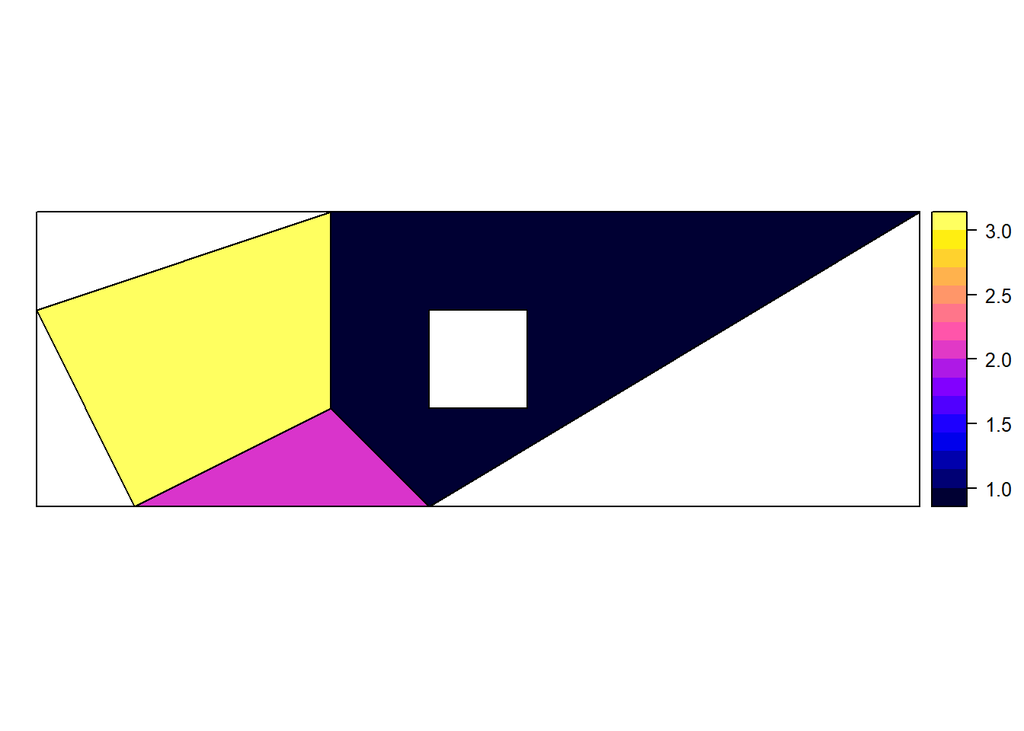

```r
spplot(SrDf)# the function spplot() is a method for plotting spatial data with attributes.
```

NOTE: By creating the previous spatial features from scratch, you understand the basic logic and structure that R and the other software use to create spatial data. This information could be important when you start to analyze your own data.

# **Loading and operating existing shapefiles into R**

The data required to visualize a single shapefile in Arc or QGIS is split into many files (e.g., cpg, .dbf, .prj, etc.), the most known of which is the sacred .SHP file (do you know the function of the other files?). To get all this info into an organized spatial object in R is easy, and in fact, as is often the case in R, there are multiple packages and functions that will do this for you. Here are a few of the most used options to read .SHP of the packages rgdal, maptools, raster, and sf:

```r
library(rgdal)
DEPARTMENTS_1 = readOGR(dsn = ".", layer = "MGN_DPTO_POLITICO") #no .shp required
```

```r
library(maptools)
DEPARTMENTS_2 = readShapePoly("MGN_DPTO_POLITICO.shp")
library(raster)
DEPARTMENTS_3 = shapefile("MGN_DPTO_POLITICO.shp")

library(sf)
DEPARTMENTS_4 = st_read("MGN_DPTO_POLITICO.shp")
```

I am partial to the shapefile() function from the raster package because it says exactly what it does. However, the use the rgdal option is the most appropriate for large or complex shapefiles with multiple layers because of its efficiency to operate. Therefore, we are going to work with DEPARTMENT_1 from this point of the tutorial. By using the function summary(), you can see the information of the SHP; R has read the shapefile as a SpatialPolygonsDataFrame. You also can see 1) the bounding box at coordinates, 2) the geographic projection at proj4string, and 3) the data attributes with some general statistics (depending on the type of attribute: numeric, character, other). You can also plot to observe this shapefile. NOTE: Remember that you learned several ways to plot a shapefile in the previous tutorial; you can try to use those ways to plot later.

```r
summary(DEPARTMENTS_1)
```

```
## Object of class SpatialPolygonsDataFrame
## Coordinates:
##          min       max
## x -81.735621 -66.84722
## y  -4.229406  13.39473
## Is projected: FALSE
## proj4string : [+proj=longlat +datum=WGS84 +no_defs]
## Data attributes:
##   DPTO_CCDGO         DPTO_CNMBR         DPTO_ANO_C         DPTO_ACT_A
##  Length:33          Length:33          Length:33          Length:33
##  Class :character   Class :character   Class :character   Class :character
##  Mode  :character   Mode  :character   Mode  :character   Mode  :character
##
##
##
##
##    DPTO_NAREA         DPTO_CSMBL         DPTO_VGNC           SHAPE_AREA
##  Min.   :    49.42   Length:33          Length:33          Min.   :0.00405
##  1st Qu.: 20619.01   Class :character   Class :character   1st Qu.:1.67949
##  Median : 24139.40   Mode  :character   Mode  :character   Median :1.96503
##  Mean   : 34574.78                                         Mean   :2.81313
##  3rd Qu.: 48353.22                                         3rd Qu.:3.93974
##  Max.   :109497.05                                         Max.   :8.87748
##
##    SHAPE_LEN            AREA
##  Min.   : 0.6853   Min.   : NA
##  1st Qu.: 9.5497   1st Qu.: NA
##  Median :12.5785   Median : NA
##  Mean   :12.7108   Mean   :NaN
##  3rd Qu.:17.2926   3rd Qu.: NA
##  Max.   :25.3560   Max.   : NA
##                    NA's   :33
```

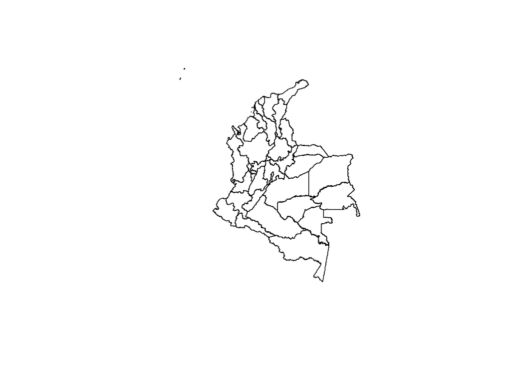

```r
plot(DEPARTMENTS_1)
```

In R, the objects contain slots (as we saw in the previous exercises related to spatial objects from scratch), which store different types of information or even functions specific to the object. We access different slots using the @ symbol. Let’s look at some of the slots stored in our DEPARTMENTS_1 object:

```r
class(DEPARTMENTS_1@data)
```

```
## [1] "data.frame"
```

```r
DEPARTMENTS_1@data
```

```
##    DPTO_CCDGO                                               DPTO_CNMBR
## 0          05                                                ANTIOQUIA
## 1          23                                                  CÓRDOBA
## 2          27                                                    CHOCÓ
## 3          70                                                    SUCRE
## 4          08                                                ATLÁNTICO
## 5          13                                                  BOLÍVAR
## 6          47                                                MAGDALENA
## 7          20                                                    CESAR
## 8          44                                               LA GUAJIRA
## 9          19                                                    CAUCA
## 10         76                                          VALLE DEL CAUCA
## 11         41                                                    HUILA
## 12         18                                                  CAQUETÁ
## 13         50                                                     META
```

[output cut: 87 more lines]

```r
DEPARTMENTS_1@proj4string
```

```
## Coordinate Reference System:
## Deprecated Proj.4 representation: +proj=longlat +datum=WGS84 +no_defs
## WKT2 2019 representation:
## GEOGCRS["WGS 84",
##     DATUM["World Geodetic System 1984",
##         ELLIPSOID["WGS 84",6378137,298.257223563,
##             LENGTHUNIT["metre",1]]],
##     PRIMEM["Greenwich",0,
##         ANGLEUNIT["degree",0.0174532925199433]],
##     CS[ellipsoidal,2],
##         AXIS["latitude",north,
##             ORDER[1],
##             ANGLEUNIT["degree",0.0174532925199433]],
##         AXIS["longitude",east,
##             ORDER[2],
##             ANGLEUNIT["degree",0.0174532925199433]],
##     ID["EPSG",4326]]
```

```r
#DEPARTMENTS_1@polygons #Try it also
```

## **Some polygon operations**

### **Subset**

The first main polygon operation is the subset of attributes. We are going o use the function subset(). Remember to add doble equals “==” to select the department (META) other way the selection fail.

```r
names(DEPARTMENTS_1)# To see the names of the attributes.
```

```
##  [1] "DPTO_CCDGO" "DPTO_CNMBR" "DPTO_ANO_C" "DPTO_ACT_A" "DPTO_NAREA"
##  [6] "DPTO_CSMBL" "DPTO_VGNC"  "SHAPE_AREA" "SHAPE_LEN"  "AREA"
```

```r
head(DEPARTMENTS_1)# To see the first five rows
```

```
##   DPTO_CCDGO DPTO_CNMBR DPTO_ANO_C                        DPTO_ACT_A DPTO_NAREA
## 0         05  ANTIOQUIA       1886     Constitucion Politica de 1886   62804.71
## 1         23    CÓRDOBA       1951 Ley 9 del 18 de Diciembre de 1951   25086.55
## 2         27      CHOCÓ       1947 Ley 13 del 3 de Noviembre de 1947   48353.22
## 3         70      SUCRE       1966    Ley 47 del 8 de Agosto de 1966   10591.85
## 4         08  ATLÁNTICO       1910                    Ley 21 de 1910    3313.81
## 5         13    BOLÍVAR       1886     Constitucion Politica de 1886   26719.21
##   DPTO_CSMBL DPTO_VGNC SHAPE_AREA SHAPE_LEN AREA
## 0          3      2020  5.1349154 21.443794   NA
## 1          3      2020  2.0575332  9.691516   NA
## 2          3      2020  3.9397431 20.634463   NA
## 3          3      2020  0.8708103  8.570869   NA
## 4          3      2020  0.2737698  2.544651   NA
## 5          3      2020  2.1955769 16.234817   NA
```

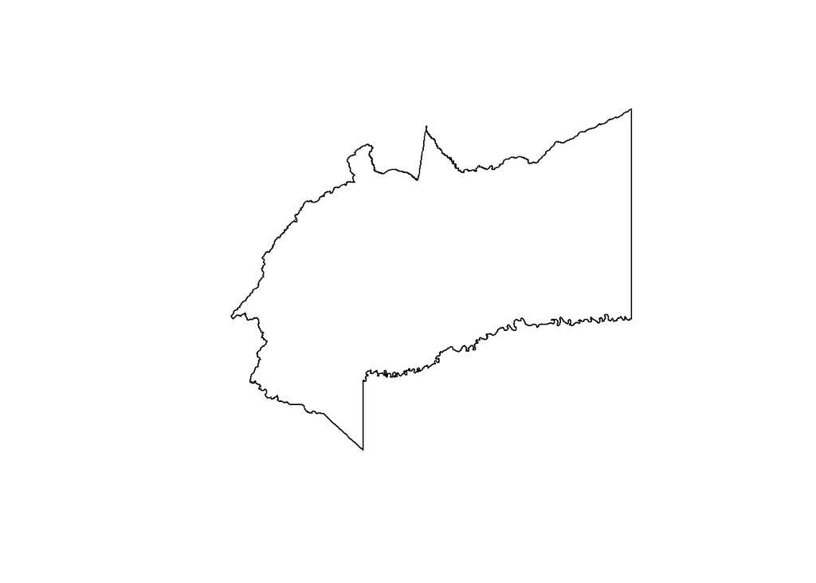

```r
META = subset(DEPARTMENTS_1, DPTO_CNMBR == "META")
plot(META)
```

```r
META
```

```
## class       : SpatialPolygonsDataFrame
## features    : 1
## extent      : -74.93335, -71.07753, 1.62084, 4.899101  (xmin, xmax, ymin, ymax)
## crs         : +proj=longlat +datum=WGS84 +no_defs
## variables   : 10
## names       : DPTO_CCDGO, DPTO_CNMBR, DPTO_ANO_C,                          DPTO_ACT_A,   DPTO_NAREA, DPTO_CSMBL, DPTO_VGNC,    SHAPE_AREA,     SHAPE_LEN, AREA
## value       :         50,       META,       1959, Ley 118 del 16 de Diciembre de 1959, 82799.176704,          3,      2020, 6.73363487204, 18.1909537045,   NA
```

You can also select two or more specific departments by their names.

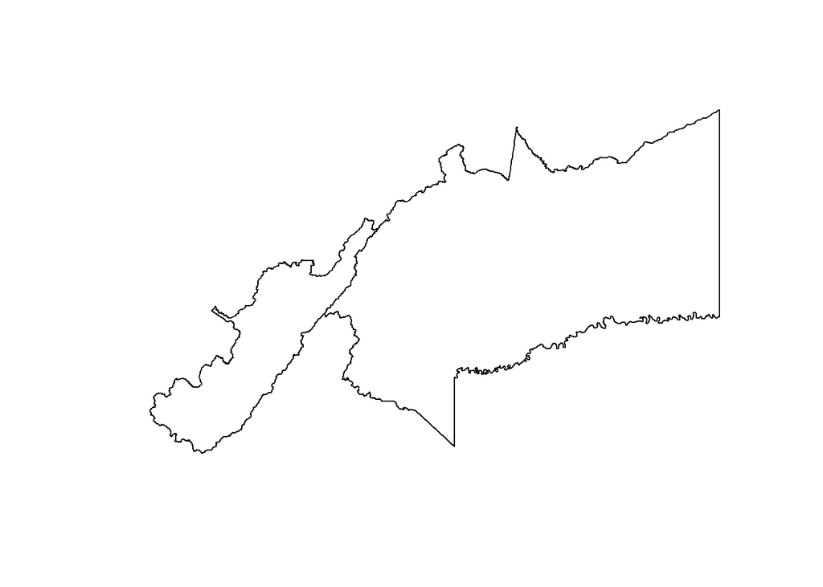

```r
META_HUILA = subset(DEPARTMENTS_1, DPTO_CNMBR == "META" | DPTO_CNMBR == "HUILA")
plot(META_HUILA)
```

```r
META_HUILA
```

```
## class       : SpatialPolygonsDataFrame
## features    : 2
## extent      : -76.62466, -71.07753, 1.552125, 4.899101  (xmin, xmax, ymin, ymax)
## crs         : +proj=longlat +datum=WGS84 +no_defs
## variables   : 10
## names       : DPTO_CCDGO, DPTO_CNMBR, DPTO_ANO_C,                          DPTO_ACT_A,    DPTO_NAREA, DPTO_CSMBL, DPTO_VGNC,    SHAPE_AREA,     SHAPE_LEN, AREA
## min values  :         41,      HUILA,       1905, Ley 118 del 16 de Diciembre de 1959, 18141.6605485,          3,      2020, 1.47421917699, 10.3355645749,   NA
## max values  :         50,       META,       1959,                      Ley 46 de 1905,  82799.176704,          3,      2020, 6.73363487204, 18.1909537045,   NA
```

The attribute selection by subsetting is based on logical operators (e.g. ==, |, &, >=, $). You can find many guides to use this type of operators; one of these guides is in [towards data science;](https://towardsdatascience.com/the-complete-guide-to-logical-operators-in-r-9eacb5fd9abd). You can also subset by the interaction of attributes using logical operators. For instance, a group 1 with the departments larger than the average size (DPTO_NAREA; values in km2) that were created before 1950. Or a group 2 with the departments in the quartile 1 (the smallest) created after 1950.

```r
#Group 1
Size = mean(DEPARTMENTS_1$DPTO_NAREA)#To obtain the mean
Size
```

```
## [1] 34574.78
```

```r
GROUP_1 = subset(DEPARTMENTS_1, DPTO_NAREA >= mean(DEPARTMENTS_1$DPTO_NAREA) & DPTO_ANO_C <= 1950)
GROUP_1
```

```
## class       : SpatialPolygonsDataFrame
## features    : 2
## extent      : -77.88378, -73.88128, 3.964883, 8.873974  (xmin, xmax, ymin, ymax)
## crs         : +proj=longlat +datum=WGS84 +no_defs
## variables   : 10
## names       : DPTO_CCDGO, DPTO_CNMBR, DPTO_ANO_C,                        DPTO_ACT_A,    DPTO_NAREA, DPTO_CSMBL, DPTO_VGNC,    SHAPE_AREA,     SHAPE_LEN, AREA
## min values  :         05,  ANTIOQUIA,       1886,     Constitucion Politica de 1886, 48353.2190281,          3,      2020, 3.93974309301,  20.634462642,   NA
## max values  :         27,      CHOCÓ,       1947, Ley 13 del 3 de Noviembre de 1947, 62804.7102519,          3,      2020,  5.1349154118, 21.4437936323,   NA
```

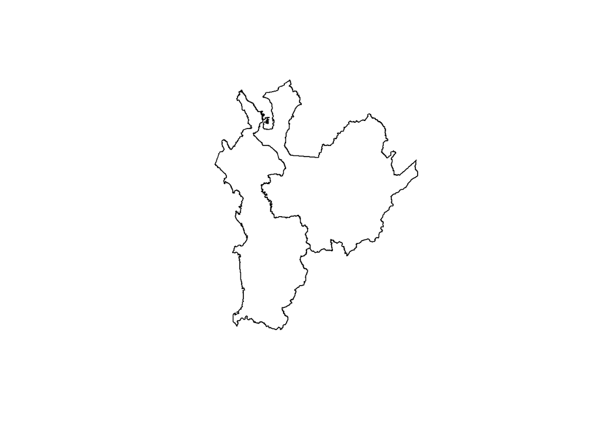

```r
plot(GROUP_1)
```

```r
#Group 2
Qs = quantile(DEPARTMENTS_1$DPTO_NAREA) #To obtain the quartiles.
Qs
```

```
##           0%          25%          50%          75%         100%
##     49.42425  20619.00959  24139.40123  48353.21903 109497.05379
```

```r
Qs[2]
```

```
##      25%
## 20619.01
```

```r
GROUP_2 = subset(DEPARTMENTS_1, DPTO_NAREA <= Qs[2] & DPTO_ANO_C >= 1950)
GROUP_2
```

```
## class       : SpatialPolygonsDataFrame
## features    : 5
## extent      : -81.73562, -71.11296, 4.075311, 13.39473  (xmin, xmax, ymin, ymax)
## crs         : +proj=longlat +datum=WGS84 +no_defs
## variables   : 10
## names       : DPTO_CCDGO,                                               DPTO_CNMBR, DPTO_ANO_C,                                     DPTO_ACT_A,    DPTO_NAREA, DPTO_CSMBL, DPTO_VGNC,       SHAPE_AREA,      SHAPE_LEN, AREA
## min values  :         44, ARCHIPIÉLAGO DE SAN ANDRÉS, PROVIDENCIA Y SANTA CATALINA,       1964, Acto Legislativo No. 1 de Diciembre 28 de 1964,   49.42425119,          3,      2020, 0.00404989764595, 0.685259427799,   NA
## max values  :         88,                                                    SUCRE,       1991,              Ley 70 del 1 de Diciembre de 1966, 20619.0095911,          3,      2020,    1.70687449047,  10.7869048866,   NA
```

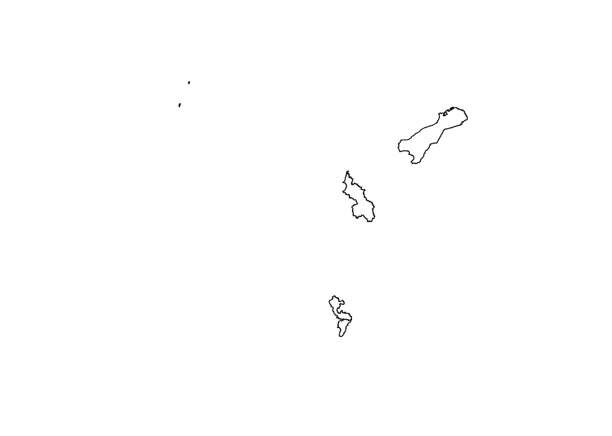

```r
plot(GROUP_2)
```

### **Crop(clip)**

You also can crop input features that overlay a clip feature. You can use crops to cut out a piece of one feature class using one or more of the features in another feature class as a cookie cutter with the function crop(). We are going to load the .SHP of the Colombian amazon region to crop the departments that are in the region.

```r
AMAZONIA = readOGR(dsn = ".", layer = "Lim_Amazonia")
DEP_AMAZONIA = crop(x = DEPARTMENTS_1, y = AMAZONIA)
DEP_AMAZONIA
```

```
## class       : SpatialPolygonsDataFrame
## features    : 21
## extent      : -77.67062, -66.84722, -4.228614, 4.948186  (xmin, xmax, ymin, ymax)
## crs         : +proj=longlat +datum=WGS84 +no_defs
## variables   : 10
## names       : DPTO_CCDGO, DPTO_CNMBR, DPTO_ANO_C,                         DPTO_ACT_A,    DPTO_NAREA, DPTO_CSMBL, DPTO_VGNC,     SHAPE_AREA,     SHAPE_LEN, AREA
## min values  :         11,   AMAZONAS,       1538,                11 de Abril de 1905,  1622.8526047,          3,      2020, 0.132207854232,  2.5548254469,   NA
## max values  :         99,    VICHADA,       1991, Ley 78 del 29 de Diciembre de 1981, 109497.053788,          3,      2020,  8.87747998889, 25.3559773719,   NA
```

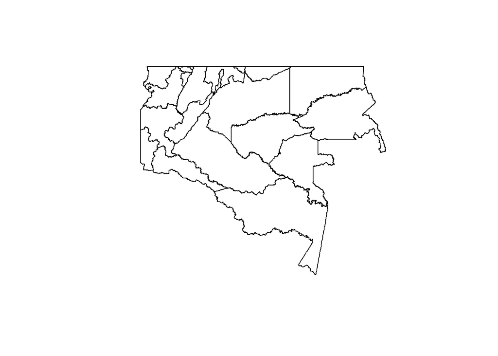

```r
plot(DEP_AMAZONIA)
```

### **Delete (erase)**

As well, you can delete polygons applying the function erase(). We are going to delate the polygon META_HUILA (create previously).

```r
COL_ERASE = erase(x = DEPARTMENTS_1, y = META_HUILA)
COL_ERASE
```

```
## class       : SpatialPolygonsDataFrame
## features    : 31
## extent      : -81.73562, -66.84722, -4.229406, 13.39473  (xmin, xmax, ymin, ymax)
## crs         : +proj=longlat +datum=WGS84 +no_defs
## variables   : 10
## names       : DPTO_CCDGO, DPTO_CNMBR, DPTO_ANO_C,                        DPTO_ACT_A,    DPTO_NAREA, DPTO_CSMBL, DPTO_VGNC,       SHAPE_AREA,      SHAPE_LEN, AREA
## min values  :         05,   AMAZONAS,       1538,               11 de Abril de 1905,   49.42425119,          3,      2020, 0.00404989764595, 0.685259427799,   NA
## max values  :         99,    VICHADA,       1991, Ley 9 del 18 de Diciembre de 1951, 109497.053788,          3,      2020,    8.87747998889,  25.3559773719,   NA
```

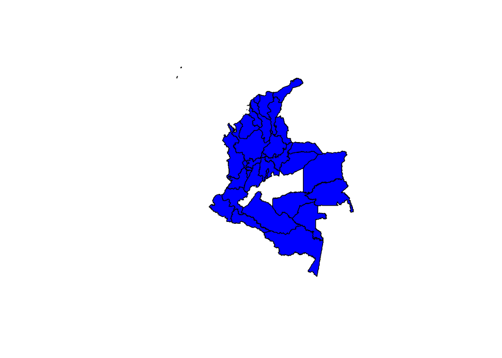

```r
plot(COL_ERASE, col ="blue")
```

### **Aggregate (dissolve)**

You can aggregate polygons in a SpatialPolygons object, according to the IDs vector specifying which input polygons belong to which output polygons; internal boundaries are dissolved. This tutorial present one options for aggregating polygons using the function gUnaryUnion() of the library rgeos. We need to read the municipalities of Colombia (MUNI) at this point of the tutorial and subset the municipalities of the department of Cauca.

```r
MUNI =  readOGR(dsn = ".", layer = "MGN_MPIO_POLITICO")
table(MUNI$DPTO_CNMBR)
```

```
##
##                                                 AMAZONAS
##                                                       11
##                                                ANTIOQUIA
##                                                      125
##                                                   ARAUCA
##                                                        7
## ARCHIPIÉLAGO DE SAN ANDRÉS, PROVIDENCIA Y SANTA CATALINA
##                                                        2
##                                                ATLÁNTICO
##                                                       23
##                                             BOGOTÁ, D.C.
##                                                        1
##                                                  BOLÍVAR
##                                                       46
##                                                   BOYACÁ
##                                                      123
##                                                   CALDAS
##                                                       27
##                                                  CAQUETÁ
##                                                       16
##                                                 CASANARE
##                                                       19
##                                                    CAUCA
##                                                       42
##                                                    CESAR
##                                                       25
##                                                    CHOCÓ
##                                                       30
##                                                  CÓRDOBA
##                                                       30
##                                             CUNDINAMARCA
##                                                      116
##                                                  GUAINÍA
##                                                        8
##                                                 GUAVIARE
##                                                        4
##                                                    HUILA
##                                                       37
##                                               LA GUAJIRA
```

[output cut: 12 more lines]

```
##                                                       12
##                                                RISARALDA
##                                                       14
##                                                SANTANDER
##                                                       87
##                                                    SUCRE
##                                                       26
##                                                   TOLIMA
##                                                       47
##                                          VALLE DEL CAUCA
##                                                       42
##                                                   VAUPÉS
##                                                        6
##                                                  VICHADA
##                                                        4
```

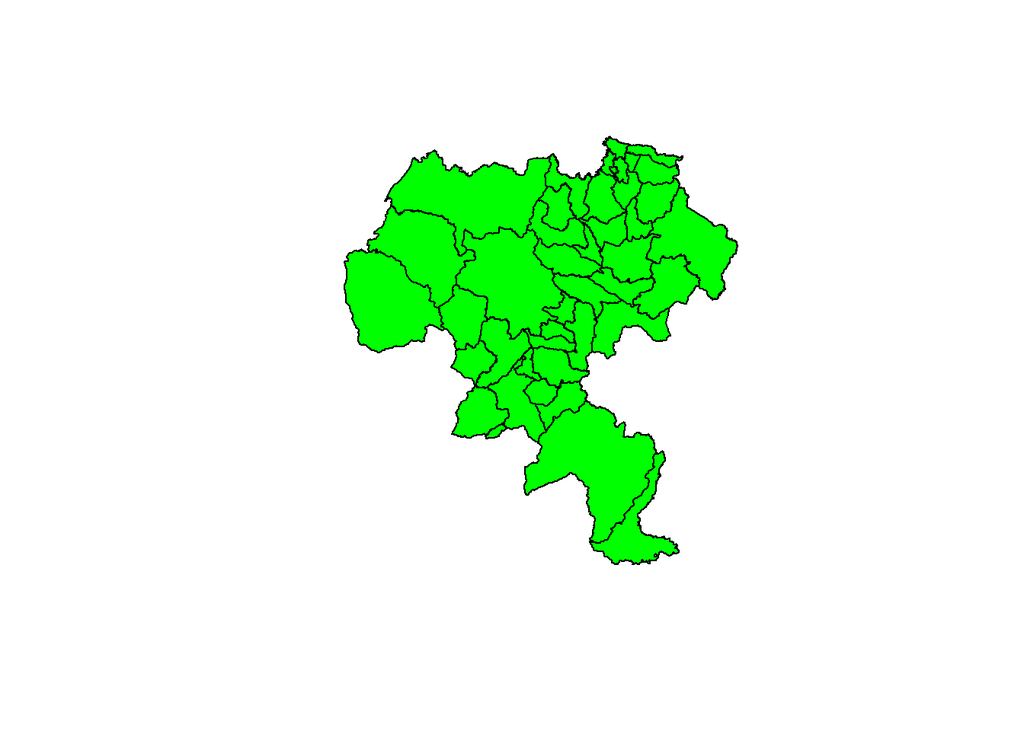

```r
CAUCA_MUNI = MUNI[MUNI$DPTO_CNMBR == "CAUCA",]
plot(CAUCA_MUNI,col = "green")
```

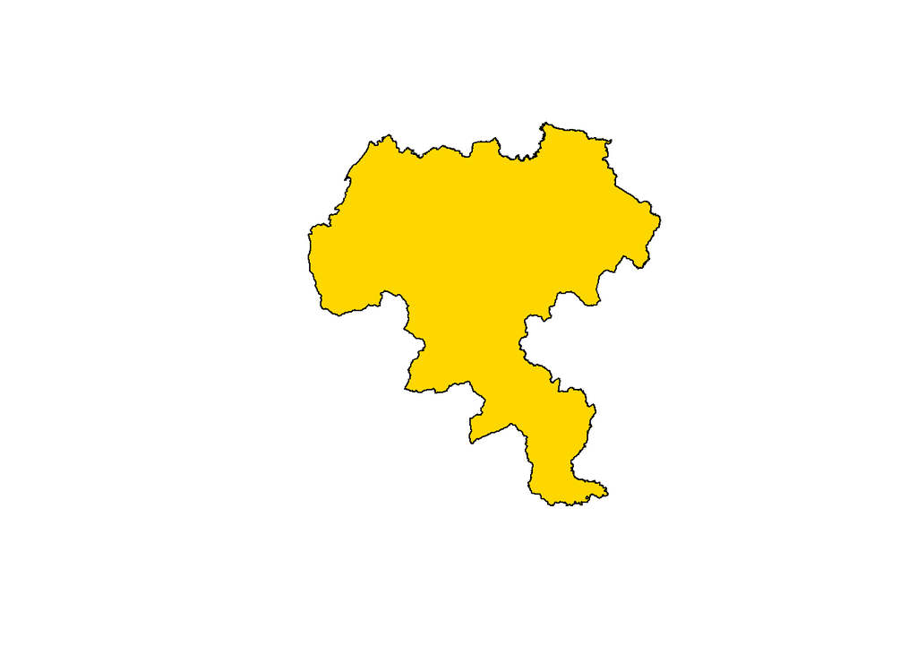

```r
library(rgeos)
CAUCA_MUNI_dis_2 = gUnaryUnion(CAUCA_MUNI)
plot(CAUCA_MUNI_dis_2, col = "gold")
```

### **Projections and centroids**

The function gCentroid() calculates the centroid of the given geometry. Let’s go to calculate them for CAUCA_MUNI

```r
CAUCA_MUNI@proj4string
```

```
## Coordinate Reference System:
## Deprecated Proj.4 representation: +proj=longlat +datum=WGS84 +no_defs
## WKT2 2019 representation:
## GEOGCRS["WGS 84",
##     DATUM["World Geodetic System 1984",
##         ELLIPSOID["WGS 84",6378137,298.257223563,
##             LENGTHUNIT["metre",1]]],
##     PRIMEM["Greenwich",0,
##         ANGLEUNIT["degree",0.0174532925199433]],
##     CS[ellipsoidal,2],
##         AXIS["latitude",north,
##             ORDER[1],
##             ANGLEUNIT["degree",0.0174532925199433]],
##         AXIS["longitude",east,
##             ORDER[2],
##             ANGLEUNIT["degree",0.0174532925199433]],
##     ID["EPSG",4326]]
```

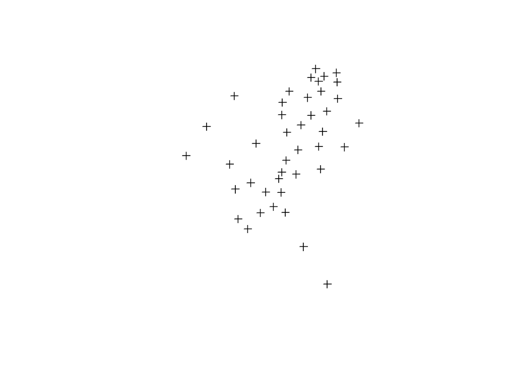

```r
CENT = gCentroid(CAUCA_MUNI, byid=TRUE)
plot(CENT)
```

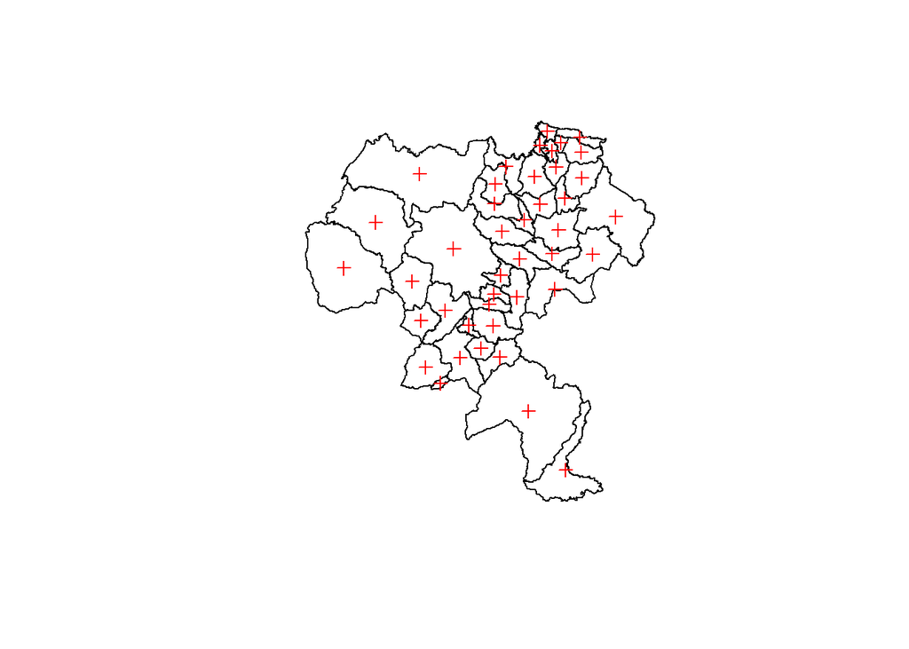

```r
plot(CAUCA_MUNI)
plot(CENT, add=T, col = "red")
```

Now, we can estimate the matrix of distances among the centroids. However, R shows a warming: Spatial object 1 is not projected; GEOS expects planar coordinates. You as spatial analyst knows that the right estimation of distances or areas needs a planar projection, and our polygons are in geographic projection.

```r
dist_matrix <- gDistance(spgeom1 = CENT, spgeom2 = NULL, byid=T)
dist_matrix[1:4, 1:4]
```

```
##           299       300      301       302
## 299 0.0000000 0.1815861 1.530989 0.1026708
## 300 0.1815861 0.0000000 1.688305 0.1822681
## 301 1.5309886 1.6883047 0.000000 1.6083476
## 302 0.1026708 0.1822681 1.608348 0.0000000
```

Therefore, we need to change the geographic projection of CAUCA_MUNI to a planar projection. We are going to use UTM at the 18-north zone, the appropriate UTM for the Cauca, using the function spTransform. See the CRS or coordinate reference system arguments, the nomenclature of this argument is explained at [here](https://www.nceas.ucsb.edu/sites/default/files/2020-04/OverviewCoordinateReferenceSystems.pdf). What is the units of the distances ?

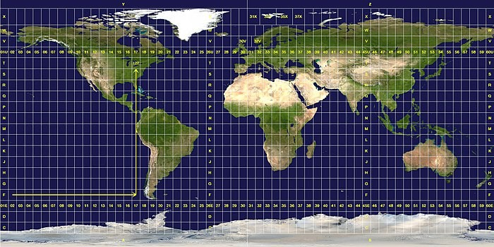

**Figure 1**. UTM zones.

```r
CAUCA_MUNI_UTM18 = spTransform(CAUCA_MUNI, CRSobj="+proj=utm +zone=18 +ellps=WGS84 +datum=WGS84 +units=m +no_defs")
proj4string(CAUCA_MUNI_UTM18)
```

```
## [1] "+proj=utm +zone=18 +datum=WGS84 +units=m +no_defs"
```

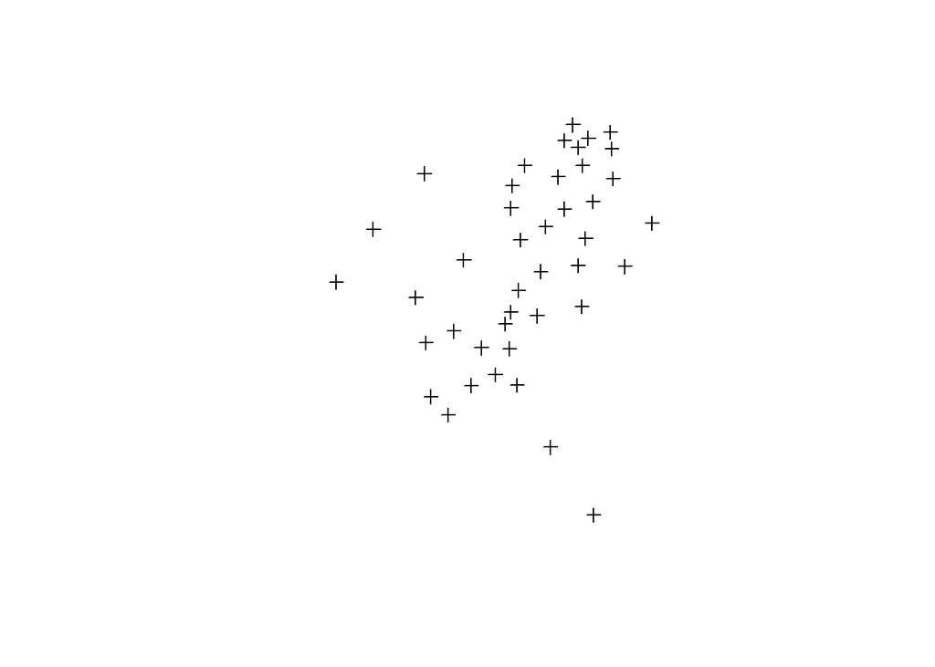

```r
CENT_UTM18 = gCentroid(CAUCA_MUNI_UTM18, byid=T)
plot(CENT_UTM18)
```

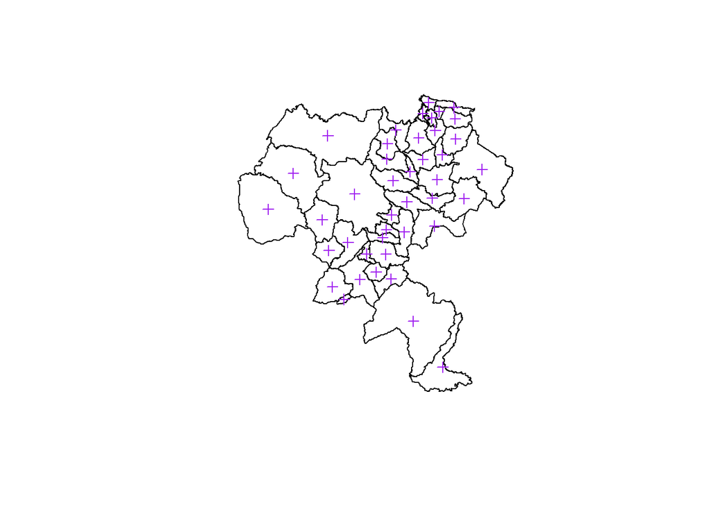

```r
#
plot(CAUCA_MUNI_UTM18)
plot(CENT_UTM18, add=T, col = "purple")
```

```r
dist_matrix_UTM18 <- gDistance(spgeom1 = CENT_UTM18, spgeom2 = NULL, byid=T)
dist_matrix_UTM18[1:4, 1:4]
```

```
##           299       300      301       302
## 299      0.00  20155.21 169521.4  11355.53
## 300  20155.21      0.00 186985.0  20256.38
## 301 169521.40 186985.05      0.0 178051.07
## 302  11355.53  20256.38 178051.1      0.00
```

Because the projection is planar, we also can estimate the areas.

```r
AREA_UTM18 <- gArea(CAUCA_MUNI_UTM18, byid=T)
AREA_UTM18
```

```
##        299        300        301        302        303        304        305
##  264286513  325348008   56525769  100473712  864837702  234025723  207923909
##        306        307        308        309        310        311        312
##  515015274  696381658  189353259  510430551   69557107 1790238326  753612832
##        313        314        315        316        317        318        319
## 1102765245  180917516  108920441  846767478  168745181  418184423  517210446
##        320        321        322        323        324        325        326
## 3612387039  679750940  514927923  391583600  135582723  200885003  491285730
##        327        328        329        330        331        332        520
##  403724395 2733595381 2561327119 3359786025 2052632936   81467763  479239409
##        521        522        523        524        525        526        527
##  236218575  773974389  412257773  796089724  434156019  551163152  354069693
```

### **Buffers**

Buffer is a technique commonly used to determine areas that are proximal to certain objects. Traditionally, buffers are circular.

```r
house_buffers_1 <- gBuffer(CENT_UTM18, width = 5000, byid = TRUE)
```

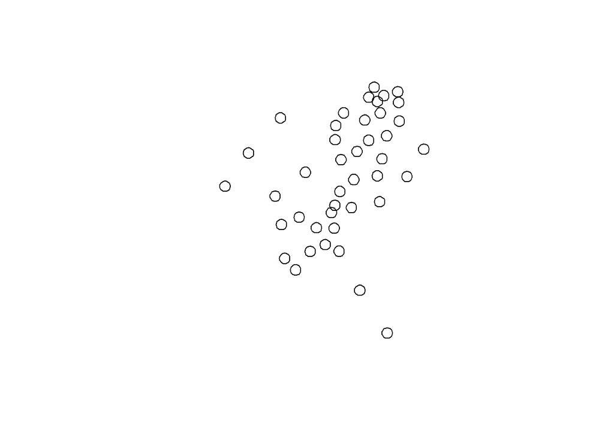

```r
plot(house_buffers_1)
```

But R is so flexible, you can obtain square and lineal buffers also. However the lineal is incompatible with SpatialPoints geometries.

```r
house_buffers_2 <- gBuffer(CENT_UTM18, width = 5000, byid = TRUE, capStyle = "SQUARE")
```

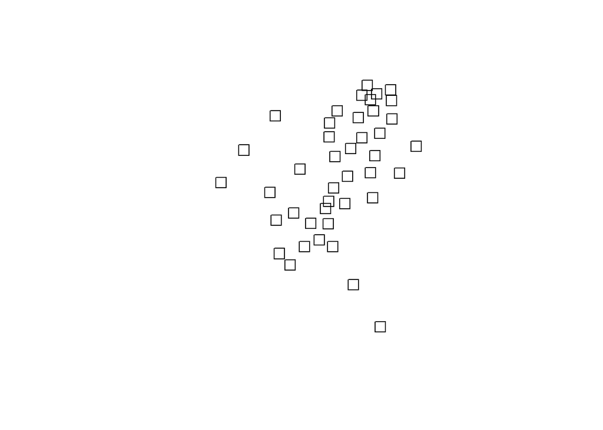

```r
plot(house_buffers_2)
```

```r
house_buffers_3 <- gBuffer(CAUCA_MUNI_UTM18, width = 5000, byid = TRUE, capStyle = "FLAT")
```

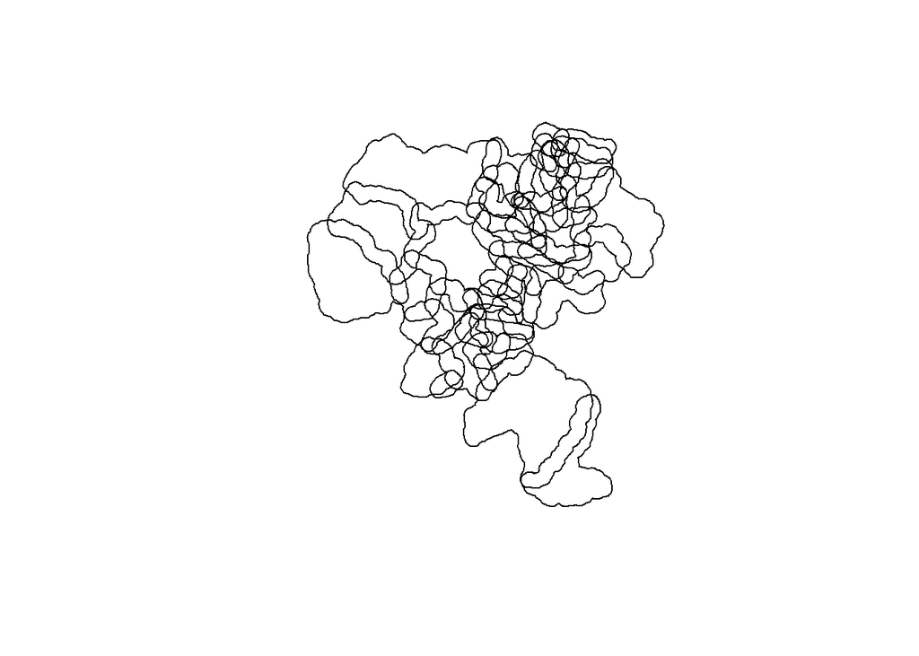

```r
plot(house_buffers_3)
```